# EP11-respuesta-equipo-2

EJEMPLO

2025-06-12

# LECTURA DE ARCHIVO

```r
datos <- read.csv2("EP09 Datos.csv")
```

# PREGUNTAS:

### Pregunta 1

> Definir la semilla a utilizar, que corresponde a los primeros cinco dígitos del RUN del integrante de mayor edad del equipo.

```r
set.seed(21063)
```

### Pregunta 2

> Seleccionar una muestra de 100 personas, asegurando que la mitad tenga estado nutricional “sobrepeso” y la otra mitad “no sobrepeso”.

```r
ICM <- datos$Weight / ((datos$Height * 0.01)^2)
datos_con_ICM <- cbind(datos, ICM)

datos_con_ICM <- datos_con_ICM %>%
  mutate(EN = factor(ifelse(ICM >= 23.2, "sobrepeso", "no sobrepeso"),
                     levels = c("no sobrepeso", "sobrepeso")))

mitad_sobrepeso <- datos_con_ICM %>%
  filter(ICM >= 23.2) %>%
  sample_n(50, replace = FALSE)

mitad_no_sobrep <- datos_con_ICM %>%
  filter(ICM < 23.2) %>%
  sample_n(50, replace = FALSE)


grup_entrenamiento <- rbind(mitad_sobrepeso, mitad_no_sobrep)  %>% sample_frac(1L)
```

### Pregunta 3

> Usando las herramientas del paquete leaps, realizar una búsqueda exhaustiva para seleccionar entre dos y ocho predictores que ayuden a estimar la > variable Peso (Weight), obviamente sin considerar las nuevas variables IMC ni EN, y luego utilizar las funciones del paquete caret para construir > un modelo de regresión lineal múltiple con los predictores escogidos y evaluarlo usando bootstrapping.

```r
datos <- grup_entrenamiento[, !(names(grup_entrenamiento) %in% c("ICM", "EN"))]

# Se realiza búsqueda exhaustiva para los predictores
modelo_subset <- regsubsets(Weight ~ ., data = datos, nvmax = 8, method = "exhaustive")
resumen_subset <- summary(modelo_subset)
print(resumen_subset$which)
```

```
##   (Intercept) Biacromial.diameter Biiliac.diameter Bitrochanteric.diameter
## 1        TRUE               FALSE            FALSE                   FALSE
## 2        TRUE               FALSE            FALSE                   FALSE
## 3        TRUE               FALSE            FALSE                   FALSE
## 4        TRUE               FALSE            FALSE                   FALSE
## 5        TRUE               FALSE            FALSE                   FALSE
## 6        TRUE               FALSE            FALSE                   FALSE
## 7        TRUE               FALSE            FALSE                   FALSE
## 8        TRUE               FALSE            FALSE                   FALSE
##   Chest.depth Chest.diameter Elbows.diameter Wrists.diameter Knees.diameter
## 1       FALSE          FALSE           FALSE           FALSE          FALSE
## 2       FALSE          FALSE           FALSE           FALSE          FALSE
## 3       FALSE          FALSE           FALSE           FALSE          FALSE
## 4       FALSE          FALSE            TRUE           FALSE          FALSE
## 5       FALSE          FALSE           FALSE           FALSE          FALSE
```

[output cut: 30 more lines]

```r
# Selecciona los mejores predictores según el bic (hay que tomar el menor valor para tener el mejor modelo)
mejor_modelo <- which.min(resumen_subset$bic)
mejores_predictores <- names(which(resumen_subset$which[mejor_modelo, ]))[-1]
print(mejores_predictores)
```

```
## [1] "Elbows.diameter"    "Chest.Girth"        "Waist.Girth"
## [4] "Thigh.Girth"        "Calf.Maximum.Girth" "Height"
```

```r
# Formula con los mejores predictores
formula <- as.formula(paste("Weight ~", paste(mejores_predictores, collapse = " + ")))

# Definir control de entrenamiento con bootstrap
control <- trainControl(method = "boot", number = 1000)  # 1000 muestras bootstrap

# Entrenar modelo
set.seed(21063)
modelo_final <- train(formula, data = datos, method = "lm", trControl = control)

# Resumen del modelo
print(modelo_final)
```

```
## Linear Regression
##
## 100 samples
##   6 predictor
##
## No pre-processing
## Resampling: Bootstrapped (1000 reps)
## Summary of sample sizes: 100, 100, 100, 100, 100, 100, ...
## Resampling results:
##
##   RMSE      Rsquared   MAE
##   2.017071  0.9780616  1.61077
##
## Tuning parameter 'intercept' was held constant at a value of TRUE
```

```r
summary(modelo_final$finalModel)
```

```
##
## Call:
## lm(formula = .outcome ~ ., data = dat)
##
## Residuals:
##     Min      1Q  Median      3Q     Max
## -4.5939 -1.1879 -0.1116  1.4018  4.2708
##
## Coefficients:
##                      Estimate Std. Error t value Pr(>|t|)
## (Intercept)        -116.92915    4.26384 -27.423  < 2e-16 ***
## Elbows.diameter       0.99697    0.27000   3.692 0.000374 ***
## Chest.Girth           0.19317    0.04481   4.311 4.04e-05 ***
## Waist.Girth           0.45430    0.03806  11.936  < 2e-16 ***
## Thigh.Girth           0.53647    0.06382   8.406 4.78e-13 ***
## Calf.Maximum.Girth    0.61305    0.11450   5.354 6.17e-07 ***
## Height                0.39162    0.03125  12.531  < 2e-16 ***
## ---
## Signif. codes:  0 '***' 0.001 '**' 0.01 '*' 0.05 '.' 0.1 ' ' 1
##
## Residual standard error: 1.873 on 93 degrees of freedom
## Multiple R-squared:  0.981,  Adjusted R-squared:  0.9798
## F-statistic: 801.6 on 6 and 93 DF,  p-value: < 2.2e-16
```

Los valores entregados por bootstrapping indican que el modelo es robusto y confiable, un R^2 de 0.978 implica que el modelo explica el 97.8% de la variabilidad de la variable Peso (Weight) en los datos de entrenamiento.

Analizando los predictores, cada uno tiene un coeficiente estadísticamente significativo, esto es que el valor p es menor a 0.05, lo que indica que cada predictor contribuye al modelo.

### Análisis de confianza del modelo:

> 1. La variable de respuesta debe ser cuantitativa y continua, sin restricciones para su variabilidad.

```r
str(grup_entrenamiento$Weight)
```

```
##  num [1:100] 57.3 72.4 60.3 46.4 78.8 63.6 83.4 91.4 50 54.3 ...
```

Se cumple con este punto, ya que la variable de respuesta es cuantitativa y continua.

Por ende, se cumple con esta condición.

> 2. Los predictores deben ser cuantitativos o dicotómicos (de ahí la necesidad de variables indicadoras para manejar más de dos niveles).

```r
str(grup_entrenamiento[, c("Elbows.diameter", "Chest.Girth", "Waist.Girth", "Thigh.Girth", "Calf.Maximum.Girth", "Height")])
```

```
## 'data.frame':    100 obs. of  6 variables:
##  $ Elbows.diameter   : num  12.6 15.2 13 11.2 13.1 13.6 14.2 15.4 12.8 12.6 ...
##  $ Chest.Girth       : num  82.2 90.9 86.8 80.3 100 ...
##  $ Waist.Girth       : num  65.8 74 69.8 65 92 72.9 88.6 88.8 59.4 64 ...
##  $ Thigh.Girth       : num  55.4 51.8 55.7 50.8 57.5 51 63.4 61 51 56.8 ...
##  $ Calf.Maximum.Girth: num  35 34.6 34.2 31.6 35.2 33.1 38.6 39.5 32.1 34 ...
##  $ Height            : num  161 188 164 158 176 ...
```

Se cumple este punto, ya que los predictores son cuantitativos y no hay variables dicotómicas.

Por ende, se cumple con esta condición.

> 3. Los predictores deben tener algún grado de variabilidad (su varianza no debe ser igual a cero). En otras palabras, no pueden ser constantes.

```r
apply(grup_entrenamiento[, c("Elbows.diameter", "Chest.Girth", "Waist.Girth", "Thigh.Girth", "Calf.Maximum.Girth", "Height")], 2, stats::var)
```

```
##    Elbows.diameter        Chest.Girth        Waist.Girth        Thigh.Girth
##           1.947071         111.753539         121.503580          15.637918
## Calf.Maximum.Girth             Height
##           7.327471          90.112948
```

Como es posible observar, la varianza de cada caso son mayores que 0.

Por ende, se cumple con esta condición.

#### Para la realización de los pasos 4, 5 y 6 es necesaria la siguiente linea de código:

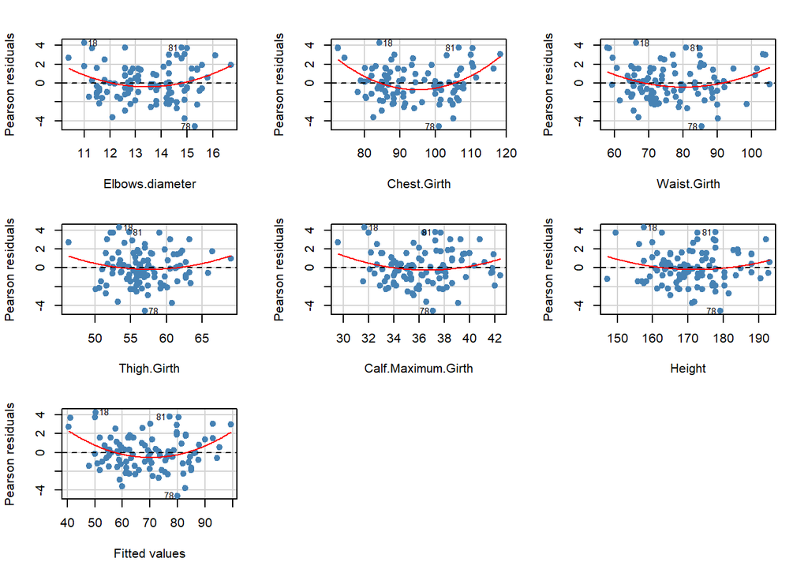

```
##                    Test stat Pr(>|Test stat|)
## Elbows.diameter       2.3816        0.0192955 *
## Chest.Girth           4.3586        3.403e-05 ***
## Waist.Girth           2.9532        0.0039922 **
## Thigh.Girth           1.3689        0.1743763
## Calf.Maximum.Girth    1.7609        0.0815804 .
## Height                1.4681        0.1454938
## Tukey test            3.5493        0.0003863 ***
## ---
## Signif. codes:  0 '***' 0.001 '**' 0.01 '*' 0.05 '.' 0.1 ' ' 1
```

```r
# Ajustar el modelo directamente con Im para diagnóstico
modelo_lm <- lm(Weight ~ Elbows.diameter + Chest.Girth + Waist.Girth + Thigh.Girth + Calf.Maximum.Girth + Height, data = grup_entrenamiento)

# Gráfico de residuos
residualPlots(modelo_lm, terms = ~ Elbows.diameter + Chest.Girth + Waist.Girth + Thigh.Girth + Calf.Maximum.Girth + Height,
              id = list(method = "r", n = 3, cex = 0.7, location = "lr"),
              col = "steelblue", pch = 19, col.quad = "red")
```

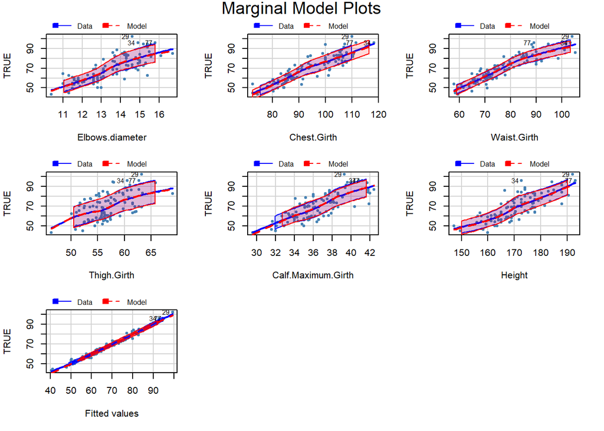

```r
# Gráficos marginales
marginalModelPlots (modelo_lm, sd = TRUE, terms = ~ Elbows.diameter + Chest.Girth + Waist.Girth + Thigh.Girth + Calf.Maximum.Girth + Height,
                    id = list(method = "r", n = 3, cex = 0.7, location = "lr"),
                    col = "steelblue", pch = 20, col.line = c("blue", "red"))
```

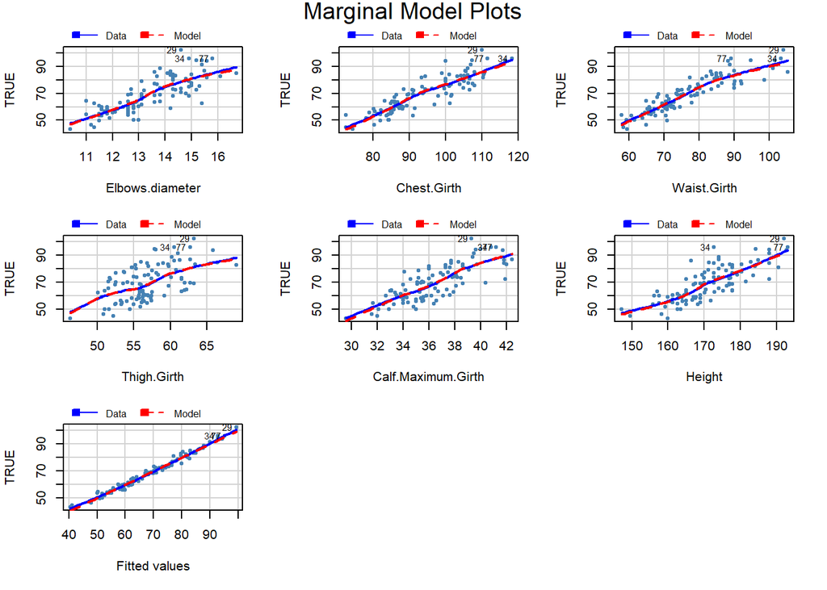

```r
mmps(modelo_lm, id = list(method = "r", n = 3, cex = 0.7, location = "lr"), col = "steelblue", pch = 20, col.line = c("blue", "red"))
```

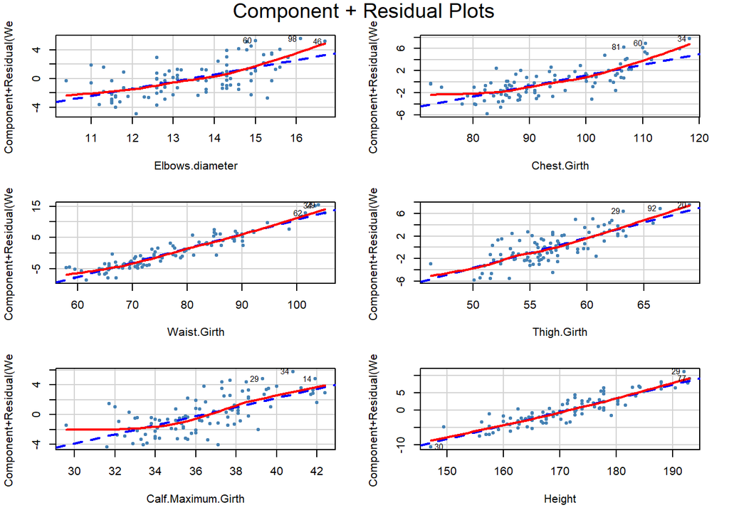

```r
# Grafico reciduos parciales
crPlots(modelo_lm, terms = ~ Elbows.diameter + Chest.Girth + Waist.Girth + Thigh.Girth + Calf.Maximum.Girth + Height,
          id = list(method = "r", n = 3, cex = 0.7, location = "lr"),
          col = "steelblue", pch = 20, col.line = c("blue", "red"))
```

> 4. Cada predictor debe estar relacionado linealmente con la respuesta.

Como es posible observar en los valores p obtenidos en el análisis de residuos, los predictores “Thigh.Girth”, “Calf.Maximum.Girth” y “Height” presentan valores mayores a un nivel de significancia de 0.05, por ende no tienen evidencia contra la linealidad.

En contraste, los predictores “Elbows.diameter”, “Chest.Girth” y “Waist.Girth” presentan valores p menores a 0.05, rechazando linealidad en su relación de la variable dependiente “Weight”.

Además, el valor de Tukey test global es de 0.0003863, lo que indica que al menos uno de los predictores no está linealmente relacionado con la variable “Weight”.

Esta conclusión también se ve reforzada por la parecencia de curvatura en los gráficos de residuos.

Por ende, no se cumple con esta condición.

> 5. La distribución de los residuos debe ser cercana a la normal centrada en cero.

```r
shapiro.test(residuals(modelo_lm))
```

```
##
##  Shapiro-Wilk normality test
##
## data:  residuals(modelo_lm)
## W = 0.98783, p-value = 0.4957
```

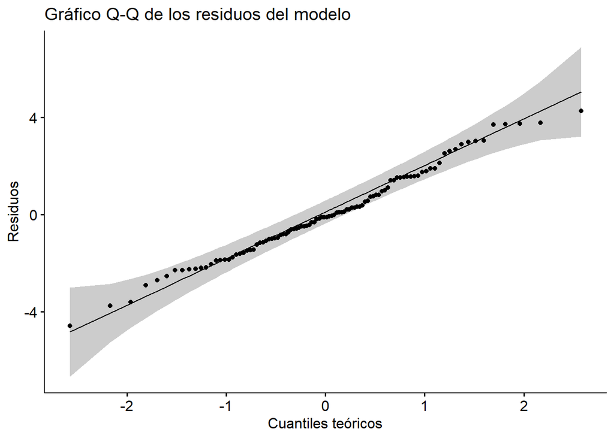

```r
ggqqplot(residuals(modelo_lm),
               ylab = "Residuos",
               xlab = "Cuantiles teóricos",
               title = "Gráfico Q-Q de los residuos del modelo")
```

La prueba de Shapiro-Wilk para normalidad de los residuos resulta tener un valor p de 0.4957, un valor mayor a un nivel de significancia del 0.05, por ende, hay evidencia suficiente para no rechazar la hipótesis nula de normalidad.

Por ende, se cumple con esta condición.

> 6. La variabilidad de los residuos debe ser aproximadamente constante (homocedasticidad).

```r
ncvTest(modelo_lm)
```

```
## Non-constant Variance Score Test
## Variance formula: ~ fitted.values
## Chisquare = 0.01704563, Df = 1, p = 0.89612
```

Para este caso, la prueba de homocedasticidad resulta tener un valor p de 0.89612, un valor mayor a un nivel de significancia del 0.05, por ende, hay evidencia suficiente para no rechazar la hipótesis nula de homocedasticidad.

Por ende, se cumple con esta condición.

> 7. Los residuos deben ser independientes entre sí.

```r
durbinWatsonTest(modelo_lm)
```

```
##  lag Autocorrelation D-W Statistic p-value
##    1      -0.1083947      2.202942   0.292
##  Alternative hypothesis: rho != 0
```

Como el valor p de la prueba de Durbin Watson resulta ser de 0.292, siendo también este mayor a un nivel de significancia de 0.05, esto significa que no hay evidencia para rechazar la hipótesis nula de independencia de los residuos, lo que sugiere que los residuos son independientes.

De igual forma el intervalo de Durbin Watson es mayor a 2, siendo este 2.202942, por ende no es necesario realizar correcciones.

Por ende, se cumple con esta condición.

> 8. No debe existir multicolinealidad. Esto significa que no deben darse relaciones lineales fuertes (co- eficientes de correlación altos) entre dos o más predictores.

```r
# INFLACIÓN DE VARIANZA:
print(vif(modelo_lm)%>%
  sort(decreasing = TRUE))
```

```
##        Chest.Girth        Waist.Girth    Elbows.diameter Calf.Maximum.Girth
##           6.330928           4.965824           4.004487           2.710190
##             Height        Thigh.Girth
##           2.482891           1.797014
```

Como el predictor con mayor VIF es “Chest.Girth” presentando un valor de 6.330928, encontrándose en el umbral de ser mayor a 5 y menor a 10, es posible concluir que existe una multicolinealidad preocupante, la cual podría afectar significativamente los resultados del modelo.

Por ende, no se cumple con esta condición.

> 9. Las estimaciones de los coeficientes del modelo no debe estar alterados por unos pocas observaciones influyentes.

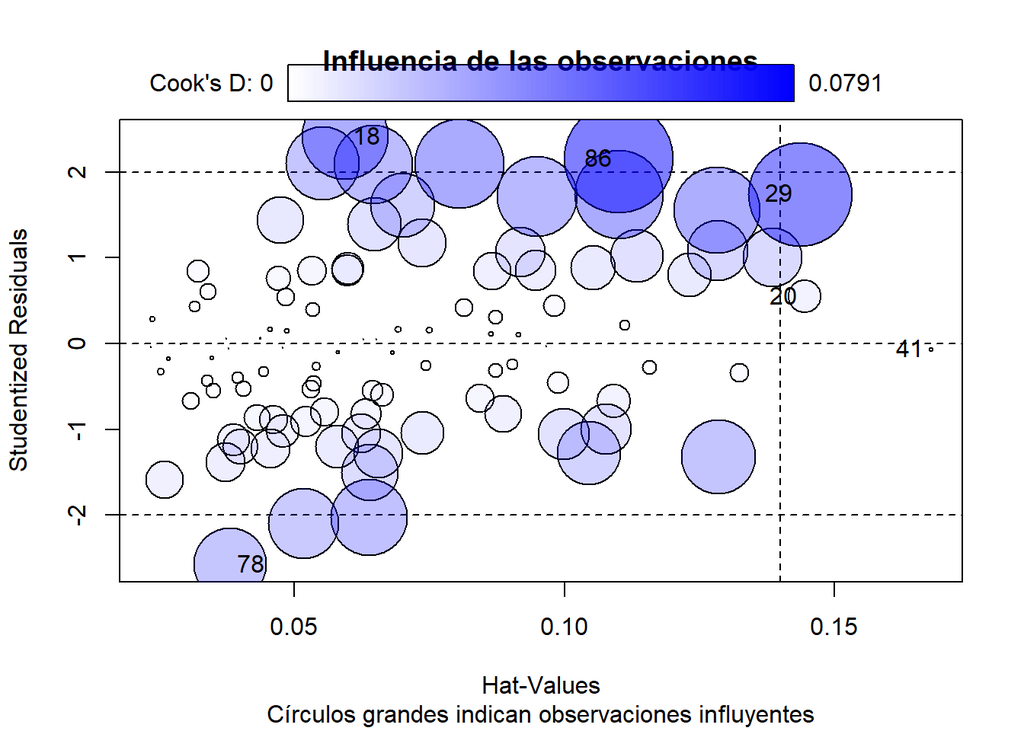

```
##        StudRes        Hat        CookD
## 18  2.41092615 0.05947042 0.0499213817
## 20  0.55143952 0.14448893 0.0073921148
## 29  1.74285892 0.14361419 0.0712101664
## 41 -0.06891387 0.16790984 0.0001383865
## 78 -2.57498922 0.03805927 0.0353375390
## 86  2.15576257 0.11012898 0.0790626781
```

```r
influencePlot(modelo_lm, id.method = "identify", main = "Influencia de las observaciones", sub = "Círculos grandes indican observaciones influyentes")
```

Es posible observar que si bien los puntos 18, 20, 29, 41, 78 y 86 destacan por sobre el resto, donde las observaciones 18 y 86 presenta residuos(StudRes) mayor a 2, la observación 78 presenta residuos(StudRes) menor a 2, pero ninguna de las seis observaciones supera el umbral crítico en la distancia de Cook, siendo todos estos menores a 1, por ende no se consideran altamente influyentes ni comprometen significativamente la validez del modelo.

### Conclusión del modelo de regresión lineal múltiple:

El modelo de regresión lineal múltiple construido no es confiable por completo, debido a que no cumple con las condiciones de:

- Relación lineral: No todos los predictores están relacionados linealmente con la respuesta. Justificado por el valor p de Tukey test global, el cual resultó se menor al nivel de significancia, lo que indica que al menos uno de los predictores no es linealmente relacionado con la variable “Weight”. Específicamente los predictores “Elbows.diameter”, “Chest.Girth” y “Waist.Girth”.
- Multicolinealidad: Hay presencia de multicolinealidad, lo que puede afectar la interpretación de los coeficientes y la estabilidad del modelo. Precisamente el predictor “Chest.Girth” que posee un VIF mayor a 5.

### Pregunta 4

> Haciendo un poco de investigación sobre el paquete caret, en particular cómo hacer Recursive Feature Elimination (RFE), construir un modelo de regresión lineal múltiple para predecir la variable IMC que incluya entre 10 y 20 predictores, seleccionando el conjunto de variables que maximice > R2 y que use cinco repeticiones de validación cruzada de cinco pliegues para evitar el sobreajuste (obviamente no se debe considerar las variables > Peso, Estatura ni estado nutricional –Weight, Height, EN respectivamente).

Según la documentación de R (https://www.rdocumentation.org/packages/caret/versions/6.0-92/topics/rfe) RFE es una técnica de selección de predictores que consiste en eliminar de forma recursiva los predictores menos relevantes para el modelo.

```r
# Elimina las variables correspondientes
datos_rfe <- grup_entrenamiento[, !(names(grup_entrenamiento) %in% c("Weight", "Height", "EN", "Gender"))]
# Formula para modelar ICM
formula_rfe <- ICM ~ .
# Repeticiones de validación cruzada con cinco pliegues
control_rfe <- rfeControl(functions = lmFuncs, method = "repeatedcv", number = 5, repeats = 5)

# Se construye el modelo RFE
set.seed(21063)
modelo_rfe <- rfe(formula_rfe, data = datos_rfe, sizes = 10:20, metric = "Rsquared", rfeControl = control_rfe)

print(modelo_rfe)
```

```
##
## Recursive feature selection
##
## Outer resampling method: Cross-Validated (5 fold, repeated 5 times)
##
## Resampling performance over subset size:
##
##  Variables  RMSE Rsquared    MAE RMSESD RsquaredSD  MAESD Selected
##         10 1.266   0.8205 1.0086 0.2228    0.05178 0.1832
##         11 1.228   0.8310 0.9790 0.2301    0.05323 0.1818
##         12 1.234   0.8292 0.9792 0.2150    0.05337 0.1746
##         13 1.188   0.8424 0.9441 0.1848    0.04541 0.1354
##         14 1.178   0.8450 0.9439 0.1854    0.04805 0.1355
##         15 1.176   0.8467 0.9404 0.1792    0.04407 0.1307
##         16 1.171   0.8484 0.9412 0.1784    0.04201 0.1353
##         17 1.178   0.8473 0.9453 0.1922    0.04383 0.1507
##         18 1.175   0.8485 0.9442 0.1792    0.04062 0.1440        *
##         19 1.179   0.8477 0.9475 0.1810    0.04138 0.1470
##         20 1.189   0.8444 0.9571 0.1843    0.04274 0.1517
##         22 1.200   0.8417 0.9671 0.1855    0.04308 0.1529
##
## The top 5 variables (out of 18):
##    Wrist.Minimum.Girth, Knees.diameter, Calf.Maximum.Girth, Knee.Girth, Biiliac.diameter
```

```r
summary(modelo_rfe$fit)
```

```
##
## Call:
## lm(formula = y ~ ., data = tmp)
##
## Residuals:
##     Min      1Q  Median      3Q     Max
## -1.9357 -0.6015 -0.1108  0.5930  2.2408
##
## Coefficients:
##                          Estimate Std. Error t value Pr(>|t|)
## (Intercept)             -0.490837   2.612910  -0.188 0.851464
## Wrist.Minimum.Girth     -0.334447   0.237558  -1.408 0.163001
## Knees.diameter           0.213538   0.179919   1.187 0.238753
## Calf.Maximum.Girth       0.255554   0.080800   3.163 0.002200 **
## Knee.Girth              -0.197792   0.087965  -2.249 0.027259 *
## Biiliac.diameter        -0.180988   0.068440  -2.644 0.009823 **
## Ankles.diameter         -0.141081   0.183316  -0.770 0.443774
## Wrists.diameter         -0.021110   0.275609  -0.077 0.939135
## Bitrochanteric.diameter  0.179202   0.095748   1.872 0.064873 .
## Waist.Girth              0.166575   0.024244   6.871  1.2e-09 ***
## Ankle.Minimum.Girth     -0.125747   0.099928  -1.258 0.211869
## Thigh.Girth              0.161527   0.046949   3.440 0.000921 ***
## Elbows.diameter         -0.063451   0.182911  -0.347 0.729572
## Chest.Girth              0.096980   0.036978   2.623 0.010422 *
## Forearm.Girth           -0.033149   0.144682  -0.229 0.819354
## Biacromial.diameter     -0.097474   0.059093  -1.650 0.102918
## Chest.diameter           0.043093   0.086852   0.496 0.621121
## Bicep.Girth              0.022990   0.088770   0.259 0.796304
## Chest.depth              0.001239   0.092509   0.013 0.989350
## ---
## Signif. codes:  0 '***' 0.001 '**' 0.01 '*' 0.05 '.' 0.1 ' ' 1
##
## Residual standard error: 0.9923 on 81 degrees of freedom
## Multiple R-squared:  0.9024, Adjusted R-squared:  0.8807
## F-statistic: 41.62 on 18 and 81 DF,  p-value: < 2.2e-16
```

```r
modelo_final2 <- modelo_rfe$fit
predictors(modelo_rfe)
```

```
##  [1] "Wrist.Minimum.Girth"     "Knees.diameter"
##  [3] "Calf.Maximum.Girth"      "Knee.Girth"
##  [5] "Biiliac.diameter"        "Ankles.diameter"
##  [7] "Wrists.diameter"         "Bitrochanteric.diameter"
##  [9] "Waist.Girth"             "Ankle.Minimum.Girth"
## [11] "Thigh.Girth"             "Elbows.diameter"
## [13] "Chest.Girth"             "Forearm.Girth"
## [15] "Biacromial.diameter"     "Chest.diameter"
## [17] "Bicep.Girth"             "Chest.depth"
```

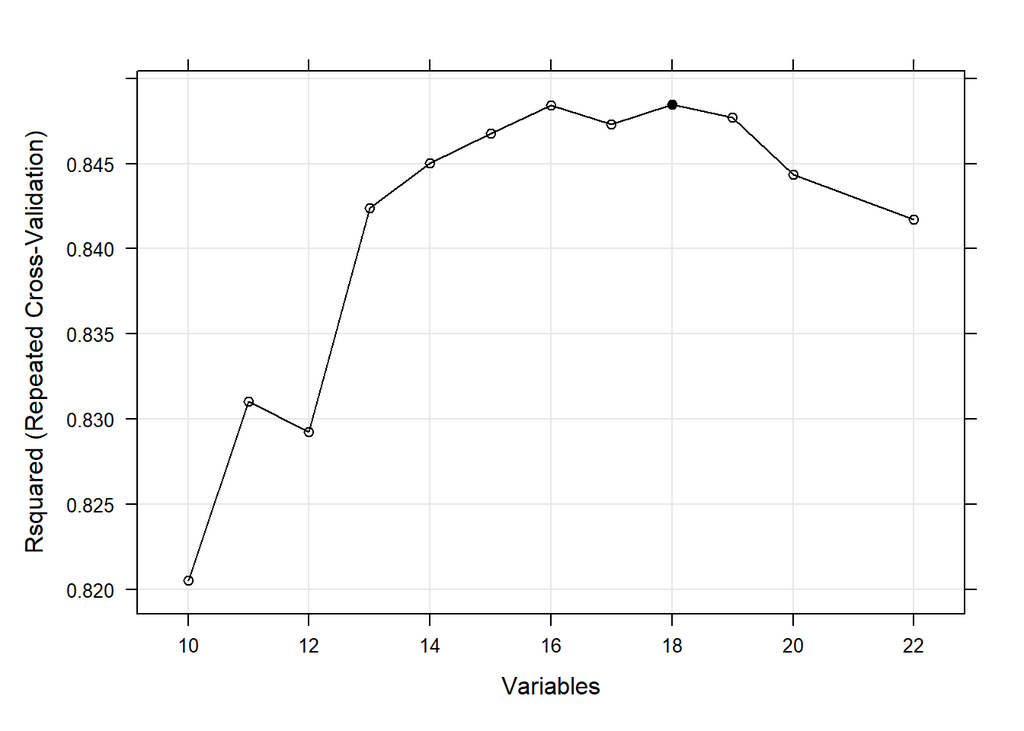

```r
trellis.par.set(caretTheme())
plot(modelo_rfe, type = c("g", "o"))
```

Encontramos los mejores 10 predictores

```r
predictores <- predictors(modelo_rfe)[1:10]
print(predictores)
```

```
##  [1] "Wrist.Minimum.Girth"     "Knees.diameter"
##  [3] "Calf.Maximum.Girth"      "Knee.Girth"
##  [5] "Biiliac.diameter"        "Ankles.diameter"
##  [7] "Wrists.diameter"         "Bitrochanteric.diameter"
##  [9] "Waist.Girth"             "Ankle.Minimum.Girth"
```

Se hace el modelo nuevamente

```r
modelo_rfe_final <- train(
  formula(paste("ICM ~", paste(predictores, collapse = " + "))),
  data = datos_rfe,
  method = "lm",
  trControl = trainControl(
    method = "repeatedcv",
    number = 5,
    repeats = 5
  )
)
```

```r
summary(modelo_rfe_final)
```

```
##
## Call:
## lm(formula = .outcome ~ ., data = dat)
##
## Residuals:
##     Min      1Q  Median      3Q     Max
## -2.5043 -0.8144 -0.1184  0.7397  3.1137
##
## Coefficients:
##                         Estimate Std. Error t value Pr(>|t|)
## (Intercept)              3.34037    2.51056   1.331   0.1867
## Wrist.Minimum.Girth     -0.36369    0.24321  -1.495   0.1384
## Knees.diameter           0.17857    0.20815   0.858   0.3932
## Calf.Maximum.Girth       0.40406    0.08872   4.554 1.66e-05 ***
## Knee.Girth              -0.08841    0.09925  -0.891   0.3754
## Biiliac.diameter        -0.17545    0.08034  -2.184   0.0316 *
## Ankles.diameter         -0.25970    0.20468  -1.269   0.2078
## Wrists.diameter          0.15907    0.31518   0.505   0.6150
## Bitrochanteric.diameter  0.14327    0.10746   1.333   0.1859
## Waist.Girth              0.23075    0.02215  10.418  < 2e-16 ***
## Ankle.Minimum.Girth     -0.19463    0.11842  -1.644   0.1038
## ---
## Signif. codes:  0 '***' 0.001 '**' 0.01 '*' 0.05 '.' 0.1 ' ' 1
##
## Residual standard error: 1.21 on 89 degrees of freedom
## Multiple R-squared:  0.8405, Adjusted R-squared:  0.8226
## F-statistic:  46.9 on 10 and 89 DF,  p-value: < 2.2e-16
```

Multicolinealidad entre los predictores

```r
print(vif(modelo_rfe_final$finalModel))
```

```
##     Wrist.Minimum.Girth          Knees.diameter      Calf.Maximum.Girth
##                8.353703                5.152695                3.898147
##              Knee.Girth        Biiliac.diameter         Ankles.diameter
##                4.100559                1.868128                4.347264
##         Wrists.diameter Bitrochanteric.diameter             Waist.Girth
##                6.825862                2.763631                4.028367
##     Ankle.Minimum.Girth
##                3.579052
```

```r
cat("\n")
```

```r
#tolerancia
print(1 / vif(modelo_rfe_final$finalModel))
```

```
##     Wrist.Minimum.Girth          Knees.diameter      Calf.Maximum.Girth
##               0.1197074               0.1940732               0.2565322
##              Knee.Girth        Biiliac.diameter         Ankles.diameter
##               0.2438692               0.5352952               0.2300297
##         Wrists.diameter Bitrochanteric.diameter             Waist.Girth
##               0.1465016               0.3618428               0.2482396
##     Ankle.Minimum.Girth
##               0.2794036
```

Se puede apreciar que existen 3 variables con problemas de multicolinealidad, el VIF de Wrist.Minimum.Girth es de 8.3 lo cual implica problemas.

Resumen del modelo

```r
print(summary(modelo_rfe_final$finalModel), digits = 3)
```

```
##
## Call:
## lm(formula = .outcome ~ ., data = dat)
##
## Residuals:
##    Min     1Q Median     3Q    Max
## -2.504 -0.814 -0.118  0.740  3.114
##
## Coefficients:
##                         Estimate Std. Error t value Pr(>|t|)
## (Intercept)               3.3404     2.5106    1.33    0.187
## Wrist.Minimum.Girth      -0.3637     0.2432   -1.50    0.138
## Knees.diameter            0.1786     0.2081    0.86    0.393
## Calf.Maximum.Girth        0.4041     0.0887    4.55  1.7e-05 ***
## Knee.Girth               -0.0884     0.0993   -0.89    0.375
## Biiliac.diameter         -0.1754     0.0803   -2.18    0.032 *
## Ankles.diameter          -0.2597     0.2047   -1.27    0.208
## Wrists.diameter           0.1591     0.3152    0.50    0.615
## Bitrochanteric.diameter   0.1433     0.1075    1.33    0.186
## Waist.Girth               0.2308     0.0221   10.42  < 2e-16 ***
## Ankle.Minimum.Girth      -0.1946     0.1184   -1.64    0.104
## ---
## Signif. codes:  0 '***' 0.001 '**' 0.01 '*' 0.05 '.' 0.1 ' ' 1
##
## Residual standard error: 1.21 on 89 degrees of freedom
## Multiple R-squared:  0.84,   Adjusted R-squared:  0.823
## F-statistic: 46.9 on 10 and 89 DF,  p-value: <2e-16
```

Se puede apreciar que únicamente 3 de los 10 predictores son estadisticamente significativos, el modelo explica un 83% de la varianza en el ICM Prueba de curvatura.

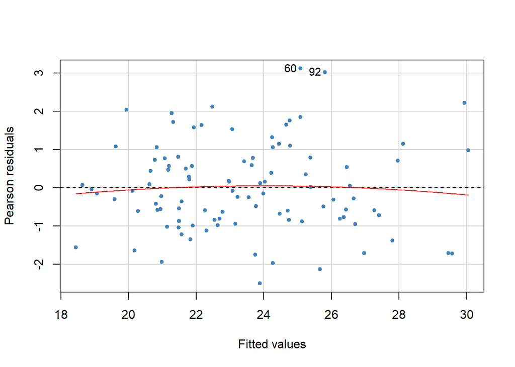

```
##            Test stat Pr(>|Test stat|)
## Tukey test   -0.5188           0.6039
```

```r
formula_final <- as.formula(paste("ICM ~", paste(predictores, collapse = " + ")))
modelo_rfe_equiv <- lm(formula_final, data = datos_rfe)
residualPlots(modelo_rfe_equiv, terms = ~ 1,
              col = "steelblue", pch = 20, col.quad = "red",
              id = list(cex = 0.9, location = "lr"))
```

Dado el valor p > 0.05, no se rechaza la hipótesis nula de linealidad. No hay evidencia estadística de curvatura en los datos.

Prueba de varianza de error no constante

```r
ncvTest(modelo_rfe_equiv)
```

```
## Non-constant Variance Score Test
## Variance formula: ~ fitted.values
## Chisquare = 3.230933, Df = 1, p = 0.07226
```

Dado el valor p, no se rechaza la hipótesis nula de homocedasticidad, la varianza de los residuos es constante Plot de influencia.

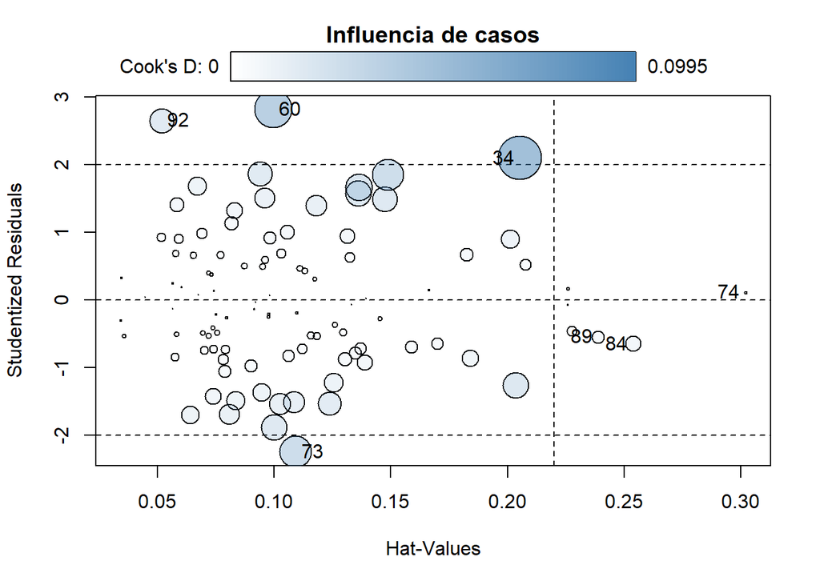

```r
modelo_inf_estad <- influencePlot(modelo_rfe_equiv, fill.col = "steelblue",
                                  scale = 5, id = list(n = 3),
                                  main = "Influencia de casos\n")
```

Gráfico marginal

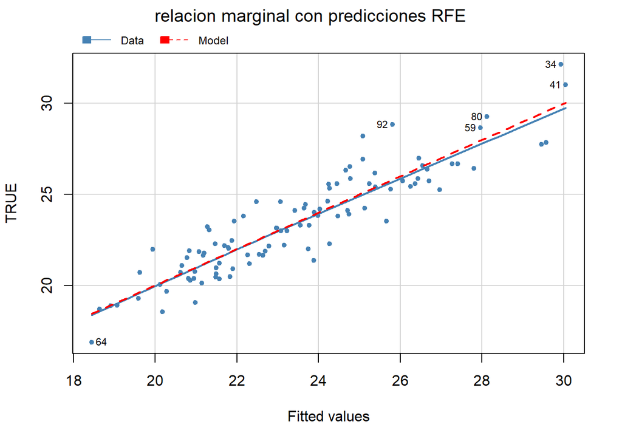

```r
mmps(modelo_rfe_equiv, terms = ~ 1,
     col = "steelblue", pch = 20, col.line = c("steelblue", "red"),
     smooth = list(smoother = loessLine, span = 1),
     id = list(n = 6, cex = 0.7, location = "lr"),
     main = "relacion marginal con predicciones RFE", sub = " ")
```

Se nota una relacion lineal fuerte.

Independencia de los residuos.

```r
print(durbinWatsonTest(modelo_rfe_equiv))
```

```
##  lag Autocorrelation D-W Statistic p-value
##    1     -0.04301142      2.072334   0.684
##  Alternative hypothesis: rho != 0
```

Dado el valor p, no se rechaza la hipótesis nula de independencia. No hay evidencia estadistica de autocorrelación en los residuos normalidad residuos.

```r
shapiro.test(resid(modelo_rfe_equiv))
```

```
##
##  Shapiro-Wilk normality test
##
## data:  resid(modelo_rfe_equiv)
## W = 0.98625, p-value = 0.3892
```

Dado el valor p, no se rechaza la hipótesis nula de normalidad. No hay evidencia estadística contra la normalidad de los residuos.

### Conclusión del modelo de regresión lineal múltiple:

Existen problemas con la multicolinealidad del modelo, los resultados no son confiables, dado el valor VIF moderado severo, se sugiere que algunas variables miden aspectos similares del cuerpo.

### Pregunta 5

> Usando RFE, construir un modelo de regresión logística múltiple para la variable EN que incluya el conjunto de predictores, entre dos y seis, que entregue la mejor curva ROC y que utilice validación cruzada dejando uno fuera para evitar el sobreajuste (obviamente no se debe considerar las variables Peso, Estatura –Weight y Height respectivamente– ni IMC).

```r
datos_log = grup_entrenamiento[, !(names(grup_entrenamiento) %in% c("Weight", "Height", "ICM", "Gender"))]
formula_log <- EN ~ .
ctrl_log <- rfeControl(functions = lrFuncs, method = "LOOCV", verbose = FALSE)

train_log <- trainControl(method = "none", classProbs = TRUE, summaryFunction = twoClassSummary)

set.seed(21063)
rfe_log <- suppressWarnings(rfe(
  formula_log,
  data = datos_log,
  sizes = 2:6,
  rfeControl = ctrl_log,
  trControl = train_log,
  metric = "ROC",
))

modelo_final3 <- rfe_log$fit
print(summary(modelo_final3))
```

```
##
## Call:
## glm(formula = Class ~ ., family = "binomial", data = tmp)
##
## Coefficients:
##                  Estimate Std. Error z value Pr(>|z|)
## (Intercept)      -47.0020    12.2173  -3.847 0.000119 ***
## Waist.Girth        0.4343     0.1054   4.122 3.76e-05 ***
## Biiliac.diameter  -0.3096     0.2460  -1.259 0.208161
## Knee.Girth        -0.1802     0.2521  -0.715 0.474643
## Thigh.Girth        0.5197     0.1787   2.909 0.003626 **
## ---
## Signif. codes:  0 '***' 0.001 '**' 0.01 '*' 0.05 '.' 0.1 ' ' 1
##
## (Dispersion parameter for binomial family taken to be 1)
##
##     Null deviance: 138.63  on 99  degrees of freedom
## Residual deviance:  43.05  on 95  degrees of freedom
## AIC: 53.05
##
## Number of Fisher Scoring iterations: 7
```

```r
# ROC y AUC
pred_probs <- predict(rfe_log, datos_log, type = "prob")
```

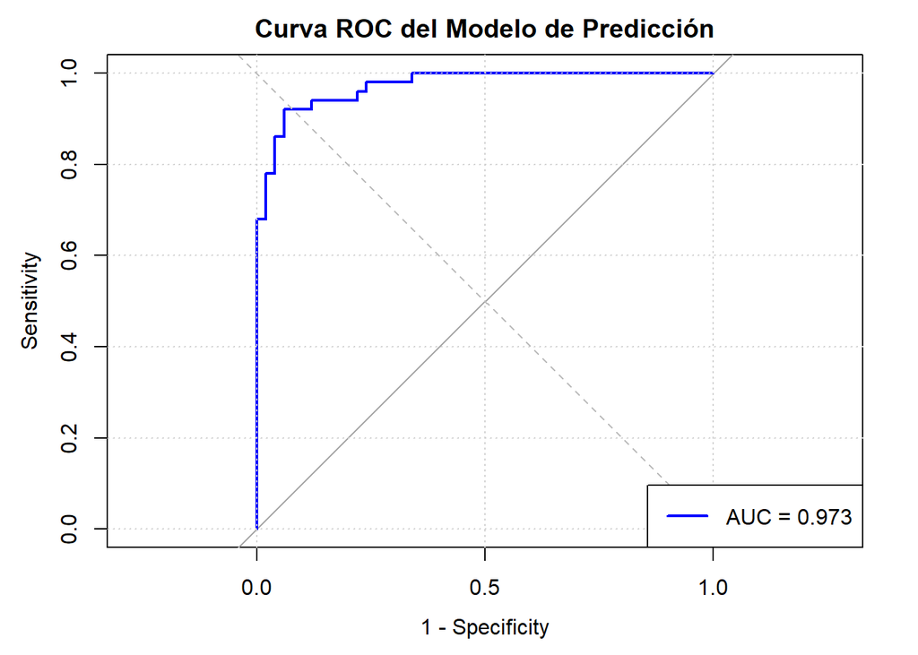

```r
roc_curve <- roc(response = datos_log$EN,
                 predictor = pred_probs[,"sobrepeso"],
                 levels = c("no sobrepeso", "sobrepeso"))
plot(roc_curve,
     main = "Curva ROC del Modelo de Predicción",
     col = "blue",
     lwd = 2,
     legacy.axes = TRUE)
grid()
abline(a = 0, b = 1, lty = 2, col = "gray")
auc_value <- auc(roc_curve)
legend("bottomright",
       legend = sprintf("AUC = %.3f", auc_value),
       col = "blue",
       lwd = 2)
```

```r
# Se extraen los predictores seleccionados, y se filtran los datos
predictores_aux <- predictors(rfe_log)
data_aux <- datos_log[, c(predictores_aux, "EN")]

# Se calculan las probabilidades de pertenencia a la clase "sobrepeso"
probabilidades <- predict(modelo_final3, newdata = data_aux, type = "response")
prediccion_clases <- factor(ifelse(probabilidades > 0.5, "sobrepeso", "no sobrepeso"),
                           levels = c("no sobrepeso", "sobrepeso"))

# Se construye matriz de confusión
conf_matrix <- confusionMatrix(prediccion_clases, data_aux$EN)
cat("\nMatriz de Confusión:\n")
```

```
##
## Matriz de Confusión:
```

```r
print(conf_matrix)
```

```
## Confusion Matrix and Statistics
##
##               Reference
## Prediction     no sobrepeso sobrepeso
##   no sobrepeso           45         4
##   sobrepeso               5        46
##
##                Accuracy : 0.91
##                  95% CI : (0.836, 0.958)
##     No Information Rate : 0.5
##     P-Value [Acc > NIR] : <2e-16
##
##                   Kappa : 0.82
##
##  Mcnemar's Test P-Value : 1
##
##             Sensitivity : 0.9000
##             Specificity : 0.9200
##          Pos Pred Value : 0.9184
##          Neg Pred Value : 0.9020
##              Prevalence : 0.5000
##          Detection Rate : 0.4500
##    Detection Prevalence : 0.4900
##       Balanced Accuracy : 0.9100
##
##        'Positive' Class : no sobrepeso
##
```

Para evaluar la confiabilidad de los modelos de regresión logística, debemos considerar varios supuestos y condiciones:

> 1. Debe existir una relación lineal entre los predictores y la respuesta transformada.

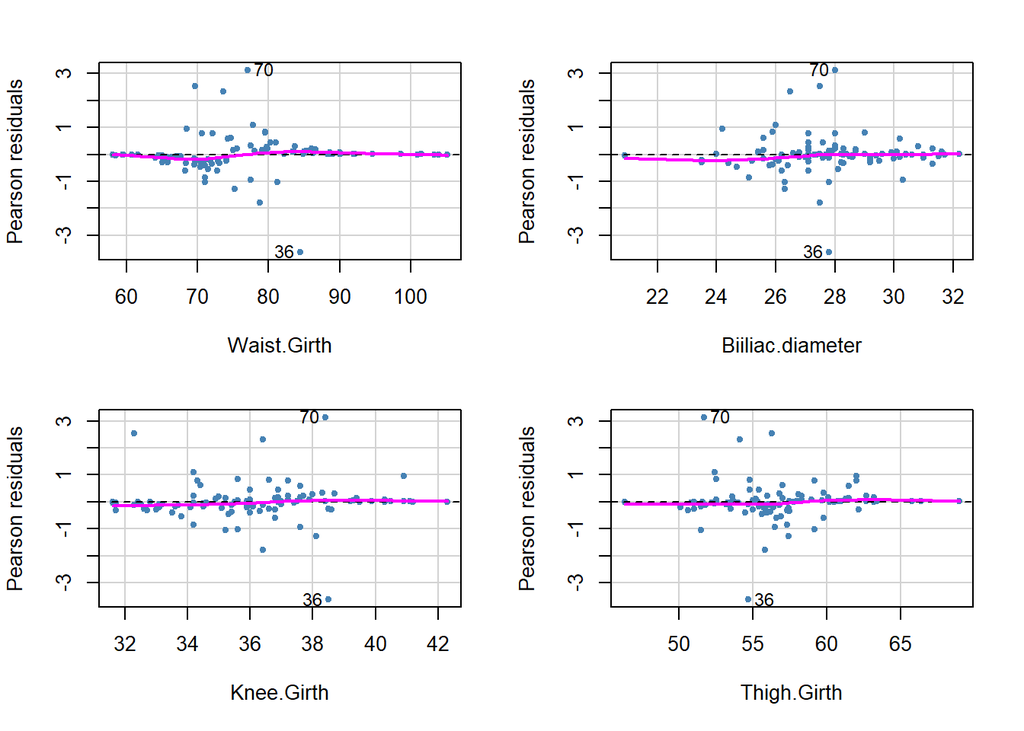

```
##                  Test stat Pr(>|Test stat|)
## Waist.Girth         0.9925          0.31912
## Biiliac.diameter    0.0581          0.80950
## Knee.Girth          1.4842          0.22311
## Thigh.Girth         2.8512          0.09131 .
## ---
## Signif. codes:  0 '***' 0.001 '**' 0.01 '*' 0.05 '.' 0.1 ' ' 1
```

```r
### ResidualPlots
# Para poder realizar residualPlots, se debe ajustar el modelo a un glm (o lm)
predictores_finales <- predictors(rfe_log)
formula_glm <- as.formula(paste("EN ~", paste(predictores_finales, collapse = " + ")))
modelo_glm <- glm(formula_glm, data = datos_log, family = binomial())

residualPlots(modelo_glm, terms = ~ .,
              col = "steelblue",
              pch = 20,
              col.quad = "red",
              id = list(cex = 0.9, location = "lr"), fitted = FALSE)
```

Dado los resultados de los residualPlots, se puede confirmar que se cumple el supuesto de linealidad entre los predictores y la respuesta obtenida. Pues todo valor p obtenido es mayor a 0.05, lo que indica que no hay evidencia suficiente para rechazar la hipótesis nula de linealidad. Además que los gráficos no presentan curvatura.

Lo que indica que este supuesto se cumple.

> 2. Los residuos deben ser independientes entre sí.

```r
durbinWatsonTest(modelo_final3)
```

```
##  lag Autocorrelation D-W Statistic p-value
##    1      0.02632633      1.945138   0.816
##  Alternative hypothesis: rho != 0
```

Dado que el valor p es de 0.816, no hay evidencia para sospechar que no se esté cumpliendo la condición de independencia de los residuos.

> 3. Multicolinealidad entre los predictores

```r
print(vif(modelo_final3))
```

```
##      Waist.Girth Biiliac.diameter       Knee.Girth      Thigh.Girth
##         1.793477         1.236656         1.568330         1.970201
```

```r
cat("\n")
```

```r
#tolerancia
print(1 / vif(modelo_final3))
```

```
##      Waist.Girth Biiliac.diameter       Knee.Girth      Thigh.Girth
##        0.5575761        0.8086321        0.6376207        0.5075623
```

Todas las variables muestran valor de inflación de la varianza por debajo de 5, lo que indica que no hay problemas de multicolinealidad severos en el modelo.

> 4. Información incompleta, que se produce cuando no contamos con observaciones suficientes para todas las posibles combinaciones de predictores, en especial para algún nivel de una variable categórica.

```r
n_obs <- nrow(datos_log)
cat("Cantidad de observaciones en el modelo:", n_obs, "\n")
```

```
## Cantidad de observaciones en el modelo: 100
```

```r
cat("Cantidad de valores NA en el conjunto de datos:", sum(is.na(datos_log)), "\n")
```

```
## Cantidad de valores NA en el conjunto de datos: 0
```

```r
predictores_log <- predictors(rfe_log)
print(predictores_log)
```

```
## [1] "Waist.Girth"      "Biiliac.diameter" "Knee.Girth"       "Thigh.Girth"
```

```r
# 4. Verificar cantidad de valores únicos por predictor seleccionado, según grupo EN
datos_log %>%
  select(all_of(c("EN", predictores_log))) %>%
  group_by(EN) %>%
  summarise(across(all_of(predictores_log), n_distinct), .groups = "drop")
```

```
## # A tibble: 2 × 5
##   EN           Waist.Girth Biiliac.diameter Knee.Girth Thigh.Girth
##   <fct>              <int>            <int>      <int>       <int>
## 1 no sobrepeso          42               37         38          38
## 2 sobrepeso             46               33         35          38
```

Como es posible observar, cada combinación de predictores presenta al menos 30 observaciones, lo que indica que no hay problemas de información incompleta en el modelo.

> 5. Separación perfecta, que ocurre cuando no hay superposición entre las clases (es decir, como vimos, cuando los predictores separan ambas clases completamente).

Es posible observar que en los gráficos de residuos se puede notar que las rectas ajustadas no están desviadas de la curva local de ajuste de los datos, “lo que indica que no hay separación perfecta”.

> 6. Las estimaciones de los coeficientes del modelo no están dominadas por casos influyentes.

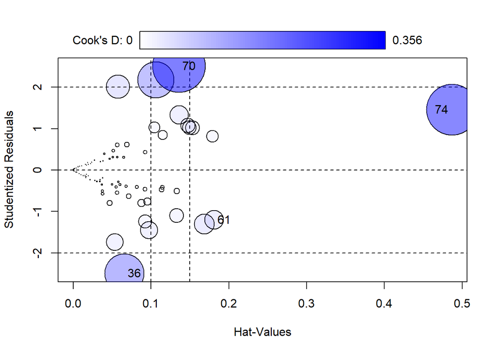

```
##      StudRes        Hat      CookD
## 36 -2.496000 0.06542476 0.19771284
## 61 -1.202979 0.18100102 0.04707894
## 70  2.508439 0.13579645 0.35566300
## 74  1.461088 0.48675056 0.33214494
```

```r
influencePlot(modelo_final3)
```

Es posible observar que si bien los puntos 36, 61, 70 y 74 destacan por sobre el resto, donde la observación 70 presenta residuos(StudRes) mayor a 2, la observación 36 presenta residuos(StudRes) menor a 2, pero ninguna de las cuatro observaciones supera el umbral crítico en la distancia de Cook, siendo todos estos menores a 1, por ende no se consideran altamente influyentes ni comprometen significativamente la validez del modelo.

Dado todas las condiciones se cumplen, se puede concluir que, los predictores no perjudican al modelo para que sea completamente confiable.

## 6) Pronunciarse sobre la confiabilidad y el poder predictivo de los modelos obtenidos.

### 2. Modelo de Regresión Lineal Múltiple para IMC:

- Confiabilidad:
  - R² = 0.83, lo que indica que el modelo explica el 83% de la variabilidad del IMC.
  - Validación cruzada (5x5) aplicada correctamente.
  - Cumple con los supuestos de normalidad, homocedasticidad, independencia y linealidad.
  - Presenta **problemas de multicolinealidad**: al menos tres predictores tienen VIF elevados (p.ej., Wrist.Minimum.Girth con VIF > 8).
- Poder Predictivo:
  - De los 10 predictores seleccionados, solo 3 resultaron estadísticamente significativos.
  - Aunque el R² es alto, la multicolinealidad limita la interpretación confiable del modelo.

### Conclusiones Generales:

En resumen, nuestro análisis destaca que el modelo logístico para EN tuvo el mejor desempeño global, mientras que el modelo de peso explicó bien la variabilidad pero incumplió supuestos clave; el modelo de IMC también mostró buen rendimiento, aunque afectado por multicolinealidad. Todos los modelos presentan buena capacidad predictiva, con validaciones robustas (bootstrapping, LOOCV y validación cruzada) y selección de variables bien aplicada. Sin embargo, enfrentamos limitaciones como multicolinealidad en modelos lineales, violación de linealidad en el modelo de peso, y algunos modelos con pocos predictores significativos. Por ello, recomendamos evaluar transformaciones para mejorar la linealidad de ciertos predictores, además de aumentar la muestra o replicar el estudio para verificar la estabilidad de las variables seleccionadas.